# NLP

Please find the code for this analysis in the notebooks located [here](https://github.com/gu-dsan6000/fall-2023-reddit-project-team-26/tree/main/code/nlp)

## Executive Summary

Our NLP analysis led us to a number of interesting conclusions regarding user sentiment in reddit data for our chosen college basketball subreddits. We used comment frequency and sentiment to analyze things like player and team popularity, how teams react to big wins and big losses, and sentiment around team successes. First we found that there were a number of very popular players, and the popularity of these players ebbed and flowed over the course of the season. We also found that popular discussion points such as the transfer portal were discussed heavily on reddit and the amount of disucssed ebbed over the course of the season.

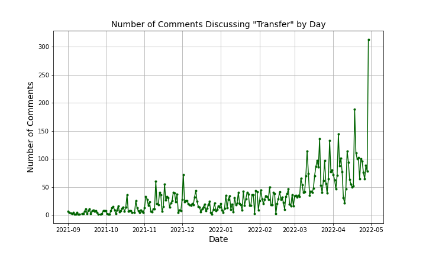

Figure 1: Disucssion of the transfer portal during the 2021-2022 season in the comments dataframe.

Then, we examined external data about how these teams were performing and compared that to how fans were feeling about their teams. We took some top teams and saw that there was a wide distribution of feeling about them, but overall, “Cinderella” teams were viewed favorably in submissions, and each team was viewed about equally in the comments. Additionally, we examined how sentiment varied over the season for the two most successful teams, Kansas and UNC. Here we visualize the sentiment for some of the top teams in the 2022 NCAA tournament.

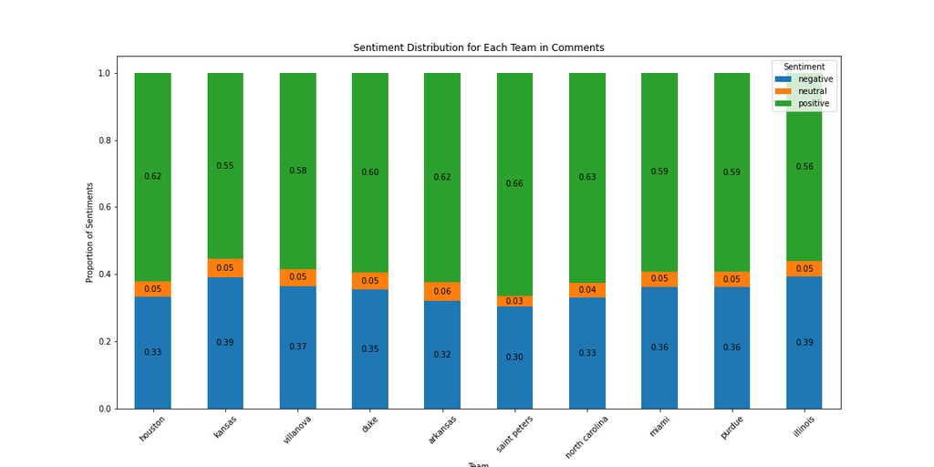

Figure 2: The percentage of comments that are positive, negative, and nuetral for top teams in the 2021-2022 season.

## Analysis Report

### Data Checks and Data Cleaning

In this section we performed standard NLP cleaning to clean reddit text data related to College Basketball. We then used that clean data to perform various analyses including identifying discussion on various topics related to college basketball, sentiment analysis of reddit posts, and linking reddit posts to the success of teams throughout the season.

Let’s look at the data before it is cleaned to get an understanding of the distribution of text data.

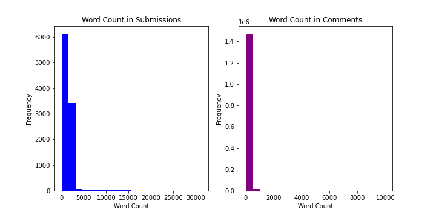

Figure 3: Distribution of text lengths in comments and submissions.

Here we see that the distribution of text lengths in submissions and comments is heavily right-skewed, but submissions are typically longer, which makes sense as people will write more in a post than in a comment.

Identifying the most common words is also interesting, but looking at unclean data means the most common words will be “the”, “and”, “a”, etc. Which is not interesting. Lets clean the data first and then look at the most common words.

The data is cleaned using the following steps: 1. Tokenize: Create tokens from each word 2. Remove Stopwords: Remove common words such as “the”, “and”, “or”, etc 3. Lower Case: convert all words to lowercase 4. Normalize: remove non-standard words and digits, including emojis 5. Lemmatize: lemmatize all words to group the same word in different forms

Using the clean data let’s look at the most common words in our reddit data

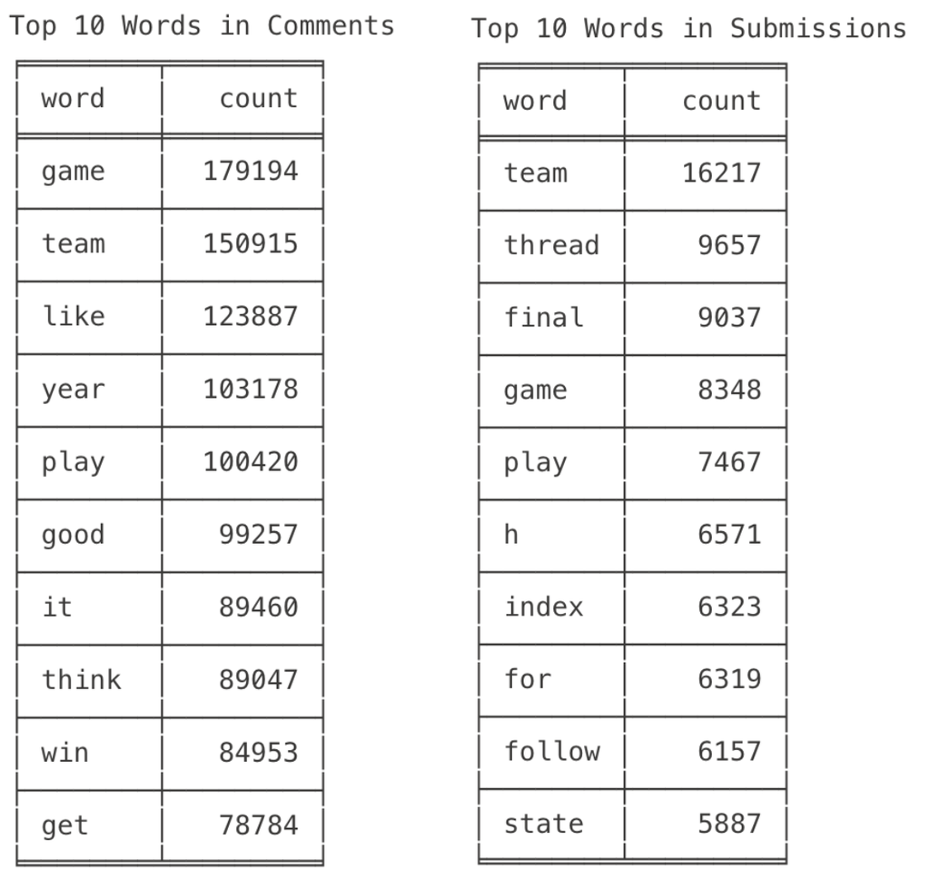

Figure 4: Most common words in comments and submissions after standard nlp cleaning.

The most common words in comments and submissions align with this being posts and comments about basketball. Words like team, game, final, and win are all sport related words. While there are differences between comments and submissions it’s not very clear that there is any pattern in the differences between the top words. We also looked at TF-IDF scores to identify the most important words, the findings of this were not as relevant with words such as: “punish”, “harris”, and “load” being the most important words so we will not further discuss those scores.

### Identifying Discussion Topics (Business Goals 4 & 5)

Two topics that are related to college basketball are the discussion about top players and the discussion of transfers and the transfer portal. We will look at both of these topics in our reddit data, using only the comments data as our submissions data is so limited. This section will answer business goals 4 and 5.

*We edited Business goal 4 to remove looking at sentiment of players because the sentiment model was not completed yet. Business goal 5 was also changed so that we are not looking at specific transfers but at the discussion around transferring as a whole which was more time efficient.*

Players, especially the best, are heavily discussed among college basketball fans. Here we look at 9 of the best players of the 2021-2022 season. We chose these players based on their selection to first or second team all America. We removed “Johnny Davis” who was on first team all america but has such a common first and last name that we were worried about picking up discussion on other players with the same name. First we looked at the number of comments that mention each of the players. Kofi Cockburn, Keegan Murray, and Drew Timme have some of the highest mentions. It is interesting to see such a large difference in player mentions among the best players. This could be related to the team the player plays for or how flashy/controversial they are.

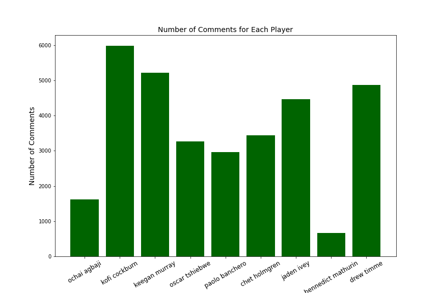

Figure 5: Number of comments in the College Basketball subreddit for each player in the 2021-2022 season. Players displayed are first/second team all americans.

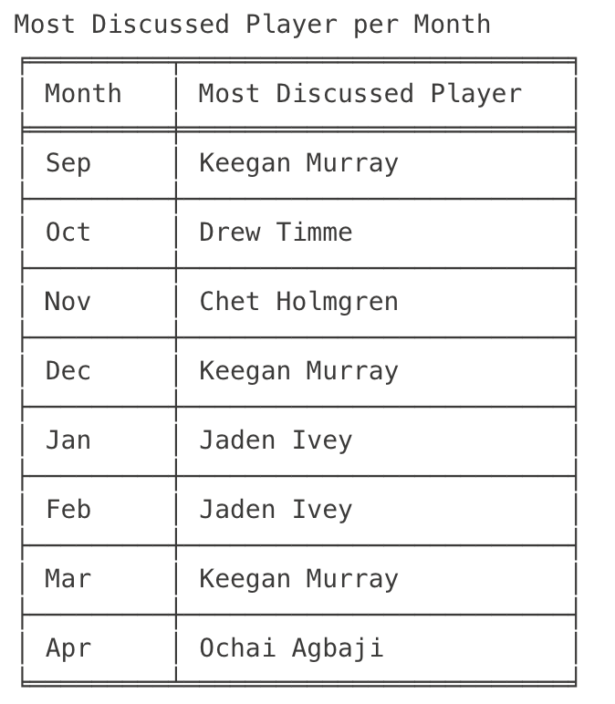

Figure 6: The most discussed player in the college basketball subreddit in each month of the 2021-2022 season.

Since the NCAA became more flexible with transfers in 2020, there has been a creation of the transfer market in College Basketball. This has led to lots of discussion among whether this is good for the players, the sport, and fans. Additionally, fans talk a lot about who might be transferring and who their team could pick up in the transfer portal. Here we see how much the transfer process is discussed over the course of the season. Transfer discussion rises from January to May, with a spike from March to May. This makes sense because most players decide to transfer after the season is over, which for most teams is in March. This means fans are very reactionary in their discussion about transfers, only talking about it when players are starting to transfer, but not so much during the regular season.

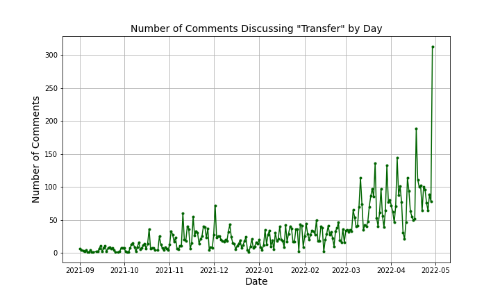

Figure 7: Disucssion of the transfer portal during the 2021-2022 season in the comments dataframe.

### Big Wins and Big Losses (Business Goal 6)

We also incorporated two datasets other than the rankings - the schedules (and win-loss records) for Kansas and UNC. These two other datasets will help us answer one of our business goals about how fans react after big wins or big losses.

Let’s examine our two subreddits to see if there are answers to our questions there. First, we take the comment frequency analysis done in question 3 of our EDA analysis as a baseline for this question. We’ll do Kansas first:

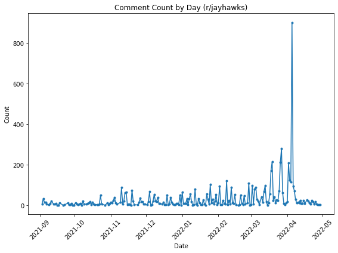

Figure 8: Number of comments per day in the 2021-2022 season in the r/jayhawks subreddit

Based on our definition of “big wins” and using the external dataset, we determined that “big wins” occurred on January 11, January 24, February 1, February 5, March 5, March 12, March 25, and April 2. There is a spike in comments on January 24, February 1, March 5, March 25, and April 2 (which is during the end-of-season tournament), but none of these spikes are anywhere close to the comment increase around the tournament championship, which makes sense. We can see that there is an increase in engagement on this subreddit when there is a “big win.”

Based on our definition of “big losses” and using the external dataset, we determined that “big losses” occurred on November 26 and March 1. Wow, very few bad losses for Kansas! On the message boards, the second bad loss has a slight spike. Kansas was blessed with a schedule with few bad losses - the fans seem to have benefitted from that as well. Now, we’ll do the same thing for the other school we selected, UNC.

[figure not shown]

Figure 9: Number of comments per day in the 2021-2022 season in the r/tarheels subreddit

Based on our definition of “big wins”, UNC had big wins on December 1, March 5, and throughout the tournament on March 19, March 25, and April 2. There were slight spikes in the number of comments on December 1 and on the tournament win dates, as well as a huge spike on the day of the loss to Kansas in the tournament. In this chart, there is a clear buildup from the beginning of March throughout the tournament - no other big wins stick out more than those. Based on our definition of “big losses”, UNC had big losses on January 5, January 18, January 22, February 16, and March 11. Many more than Kansas had! The two bad losses in a row in late January were met with a spike in comments - one of the largest up until that point. Additionally, the March 11 loss had a spike as well, probably many fans acknowledging their chagrin heading into the tournament. Overall, big wins or big losses did show up in the comment frequency, but the tournament results were a significantly larger change in comment frequency.

We will investigate whether the sentiment expressed in fan comments is influenced by the outcomes of games, particularly in cases of significant victories or defeats. This analysis will be conducted subsequent to the development and establishment of a sentiment analysis model.

### Sentiment Model

In this section, we built a sentiment model and tried to find the relationship between the team ranking and the sentiment. We employ a sentiment analysis model originally trained on Twitter data for our study. The decision to apply this model to Reddit data is grounded in the shared characteristics of both platforms, including similarities in content types, language styles, topic diversity, user engagement, and the nature of online discussions. However, it’s important to acknowledge a key difference: Twitter’s character limit often results in more succinct and occasionally cryptic language, whereas Reddit allows for lengthier and more detailed comments. This disparity in content style could potentially impact the model’s accuracy in analyzing sentiment on Reddit, a factor we’ll carefully consider in our analysis.

### Sentiment Analysis (Business Goal 7)

In our previous exploration within the EDA section, we focused on quantifying the mention frequency of ten basketball teams. In our current analysis, we delve deeper by leveraging sentiment analysis models to dissect the emotional tone embedded within submissions and comments that reference each team. This sentiment distribution offers a nuanced perspective, going beyond mere mention counts to encapsulate the nature of the discourse surrounding these teams.

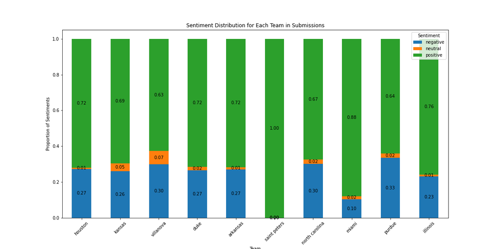

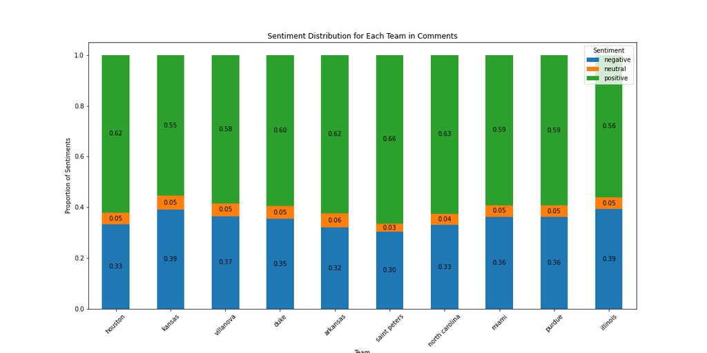

Figure 10: The percentage of comments and submissions that are positive, negative, and nuetral for top teams in the 2021-2022 season.

In both submissions and comments, a pronounced positive sentiment prevails across the board for all teams, with the positive sentiment—represented by green segments—forming the bulk of the sentiment distribution. Negative sentiments are relatively few, and neutral sentiments are even rarer. Among submissions, Saint Peters and Miami stand out with a substantially higher share of positive sentiment. However, Saint Peters’ data is limited to just four entries, casting doubts on the reliability of these results. Miami’s data is more substantial, suggesting a positive reception or favorable outcomes in related games. Yet, the unusually high volume of submissions for Miami warrants additional investigation to fully understand the drivers of this positive sentiment trend. Conversely, the sentiment distribution within comments is more uniform across teams, lacking any significant disparities.

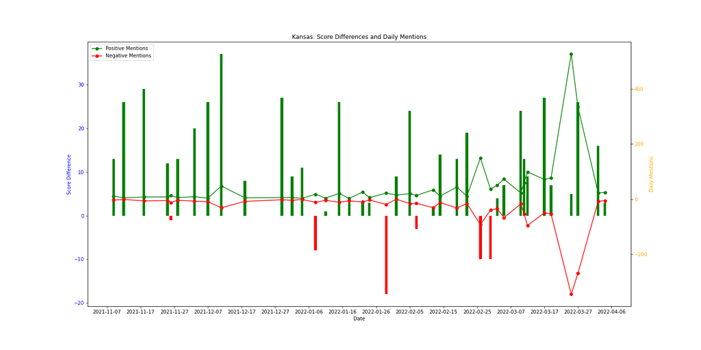

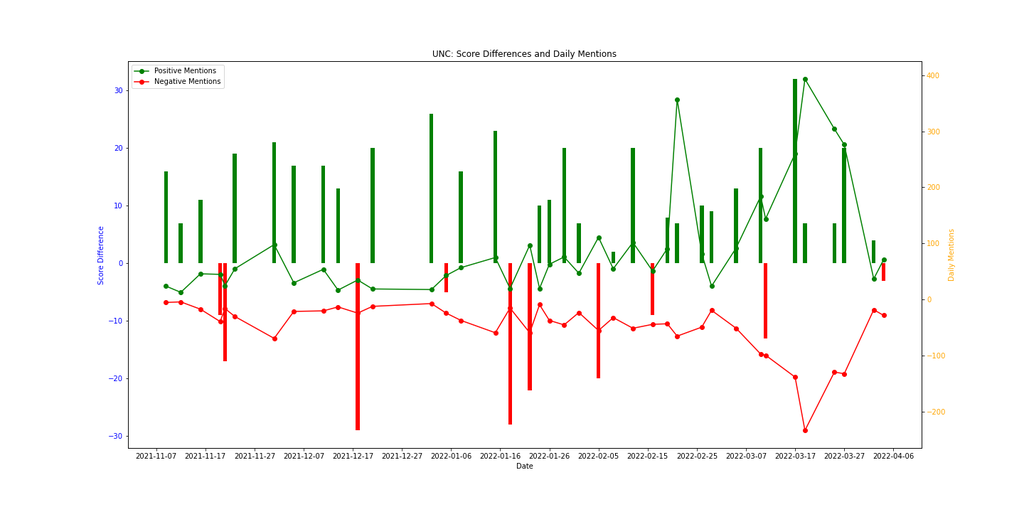

Figure 11: Point differential for Kansas and UNC compared with the sentiment of their respective subreddits in 2021-2022. Green bars indicate wins where larger wins are larger bars, whereas red bars indicate losses. The green and red lines indicate number of positive and negative posts, respectively.

Our investigation intensifies as we probe into the impact of match outcomes—especially resounding triumphs or losses—on the emotional tone within fan discourse. Focusing exclusively on Kansas and North Carolina, their status as the champion and runner-up offers a compelling lens through which to assess the interplay between on-court results and sentiment in fan commentary.

The figure suggests a weak correlation between the volume of comments and the game’s point differential. Contrary to expectations, a decisive victory doesn’t necessarily lead to an increase in positive comments or a decrease in negative ones. Similarly, a substantial defeat doesn’t always trigger a rise in negative comments or a fall in positive ones. Additionally, the trends in positive and negative comments appear to move in tandem; an increase in one typically accompanies a rise in the other, as indicated by the symmetrical nature of the lines on the chart.

Certainly, significant victories don’t always equate to substantial point differential. Consider a top-seeded team overpowering a lower-ranked opponent by a wide margin; such outcomes rarely stir enthusiasm or provoke widespread discussion. It’s crucial to factor in the caliber of the opponent and various other elements. However, even when accounting for the big wins and losses we’ve examined before(Section 4), there isn’t a discernible difference between the nature of the comments, be they positive or negative. This observation appears to reinforce our conclusion.

Additionally, it’s vital to assess the model’s effectiveness in accurately identifying the sentiments expressed in the comments. Comments on sports events may possess unique characteristics that a sentiment model, trained predominantly on Twitter data, might not capture. This discrepancy could contribute to the lack of clear distinction between positive and negative emotions in our analysis.

On another note, fan reactions to a team’s performance are often diverse and complex. A significant victory might elicit sheer joy from some fans, while others might express concern. Similarly, in the face of defeat, while some fans may express sorrow or disappointment, others might offer encouragement to the team and players, showing resilience. There’s even a possibility that the fans’ comments are indifferent to the game’s outcome, focusing instead on different aspects. This underscores the need for more comprehensive research to validate these observations.

### External Data

Our external data centered around answering our business questions by providing the weekly rankings of each team and the results throughout the year of the two teams we chose to focus on: Kansas and UNC. These results were incorporated throughout the answers to the business questions above. The rankings were interesting, especially because one of our teams, UNC, was rarely in the Top 25 (they were somewhat of a Cinderella story!). This gives us some interesting data points on how fans of teams outside of what experts view as the top teams behave. Overall, the rankings were chaotic in the 2021-2022 season, as shown here:

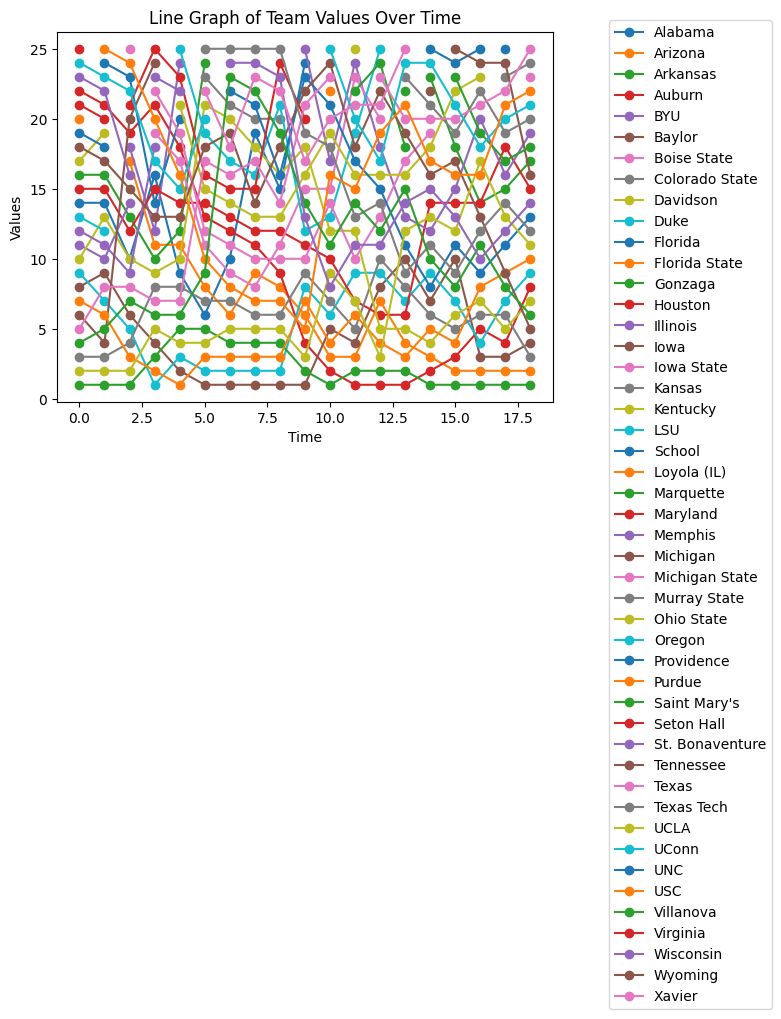

Figure 12: The AP top 25 ranking of each team over each week in the 2021-2022 college basketball season

Very few teams made it to the number one spot, and the ones that did rarely stayed there long! Although clearly these rankings don’t always mean something – shown by UNC’s run to make it all the way to the championship game despite rarely being ranked all season – it is useful to have a metric to compare teams to others, especially in the face of ecstatic fanbases.